# Manjeet Singh- KaiOS Assignment

```python
from sklearn import tree
from sklearn import svm
from sklearn import ensemble
from sklearn import neighbors
from sklearn import linear_model
from sklearn import metrics
from sklearn import preprocessing
import numpy as np
import matplotlib.pyplot as plt
import pandas as pd
import seaborn as sns
import featuretools as ft
from sklearn.linear_model import LogisticRegression
from sklearn.feature_selection import RFE
from sklearn.metrics import accuracy_score
from sklearn.ensemble import RandomForestClassifier
from sklearn.svm import SVC
from sklearn import model_selection
from sklearn.model_selection import cross_val_score
from sklearn.metrics import classification_report
from sklearn.metrics import confusion_matrix
# matplotlit and seaborn for visualizations
plt.rcParams['font.size'] = 22
# Suppress warnings from pandas
import warnings
warnings.filterwarnings('ignore')
import lightgbm as lgb
from sklearn.model_selection import train_test_split
from sklearn.model_selection import KFold
from sklearn.metrics import roc_auc_score
from sklearn.preprocessing import LabelEncoder

# memory management
import gc
```

```python
df = pd.read_csv('C:/Users/msingh/Desktop/KSDataset.csv')
```

```python
columns = df.columns.values.tolist()
print(columns)
```

```
['show_name', 'time_offset', 'r_abies', 'r_abyssinian', 'r_accessories', 'r_accipiter', 'r_acorn', 'r_adapter', 'r_adorable', 'r_adventure', 'r_aerial_view', 'r_affenpinscher', 'r_afghan_hound', 'r_african_grey_parrot', 'r_afro_hairstyle', 'r_aftershave', 'r_agaric', 'r_agavaceae', 'r_air_conditione…
```

```python
df.head()
df.dtypes
```

```
show_name           object
time_offset          int64
r_abies            float64
r_abyssinian       float64
r_accessories      float64
                    ...
r_zoo              float64
h_alcohol_str      float64
h_food_str         float64
h_hot_drink_str    float64
h_phone_str        float64
Length: 1610, dtype: object
```

```python
df = df.loc[:, (df != 0).any(axis=0)]
```

I just dropped all the feature which had only 0 values in it.

```python
df.isnull().any()
```

```
show_name          False
time_offset        False
r_abies            False
r_abyssinian       False
r_accessories      False
                   ...
r_zoo              False
h_alcohol_str      False
h_food_str         False
h_hot_drink_str    False
h_phone_str        False
Length: 1445, dtype: bool
```

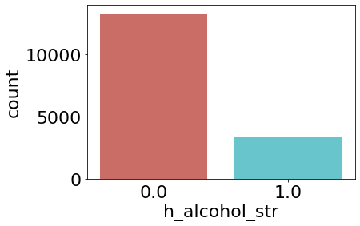

```python
sns.countplot(x='h_alcohol_str', data= df, palette ='hls')
plt.show()
plt.savefig('countplot')
```

```python
df =  df.drop(['time_offset','h_food_str','h_hot_drink_str', 'h_phone_str','show_name'], axis=1)
df
```

|  | r_abies | r_abyssinian | r_accessories | r_accipiter | r_acorn | r_adapter | r_adorable | r_adventure | r_aerial_view | r_affenpinscher | ... | r_worship | r_wrist | r_x_ray | r_yacht | r_yard | r_yew | r_zebra | r_zebra_crossing | r_zoo | h_alcohol_str |
| --- | --- | --- | --- | --- | --- | --- | --- | --- | --- | --- | --- | --- | --- | --- | --- | --- | --- | --- | --- | --- | --- |
| 0 | 0.0 | 0.0 | 0.0 | 0.0 | 0.0 | 0.0 | 0.0 | 0.0 | 0.0 | 0.0 | ... | 0.6 | 0.0 | 0.0 | 0.0 | 0.0 | 0.5 | 0.0 | 0.0 | 0.0 | 0.0 |
| 1 | 0.0 | 0.0 | 0.0 | 0.0 | 0.0 | 0.0 | 0.0 | 0.0 | 0.0 | 0.0 | ... | 0.6 | 0.0 | 0.0 | 0.0 | 0.0 | 0.5 | 0.0 | 0.0 | 0.0 | 0.0 |
| 2 | 0.0 | 0.0 | 0.0 | 0.0 | 0.0 | 0.0 | 0.0 | 0.0 | 0.0 | 0.0 | ... | 0.7 | 0.0 | 0.0 | 0.0 | 0.0 | 0.5 | 0.0 | 0.0 | 0.0 | 0.0 |
| 3 | 0.0 | 0.0 | 0.0 | 0.0 | 0.0 | 0.0 | 0.0 | 0.0 | 0.0 | 0.0 | ... | 0.6 | 0.0 | 0.0 | 0.0 | 0.0 | 0.5 | 0.0 | 0.0 | 0.0 | 0.0 |
| 4 | 0.0 | 0.0 | 0.0 | 0.0 | 0.0 | 0.0 | 0.0 | 0.0 | 0.0 | 0.0 | ... | 0.6 | 0.0 | 0.0 | 0.0 | 0.0 | 0.5 | 0.0 | 0.0 | 0.0 | 0.0 |
| ... | ... | ... | ... | ... | ... | ... | ... | ... | ... | ... | ... | ... | ... | ... | ... | ... | ... | ... | ... | ... | ... |
| 16563 | 0.0 | 0.0 | 0.0 | 0.0 | 0.0 | 0.0 | 0.0 | 0.0 | 0.0 | 0.0 | ... | 0.0 | 0.0 | 0.0 | 0.0 | 0.0 | 0.0 | 0.0 | 0.0 | 0.0 | 0.0 |
| 16564 | 0.0 | 0.0 | 0.0 | 0.0 | 0.0 | 0.0 | 0.0 | 0.0 | 0.0 | 0.0 | ... | 0.0 | 0.0 | 0.0 | 0.0 | 0.0 | 0.0 | 0.0 | 0.0 | 0.0 | 0.0 |
| 16565 | 0.0 | 0.0 | 0.0 | 0.0 | 0.0 | 0.0 | 0.0 | 0.0 | 0.0 | 0.0 | ... | 0.0 | 0.0 | 0.0 | 0.0 | 0.0 | 0.0 | 0.0 | 0.0 | 0.0 | 0.0 |
| 16566 | 0.0 | 0.0 | 0.0 | 0.0 | 0.0 | 0.0 | 0.0 | 0.0 | 0.0 | 0.0 | ... | 0.0 | 0.0 | 0.0 | 0.0 | 0.0 | 0.0 | 0.0 | 0.0 | 0.0 | 0.0 |
| 16567 | 0.0 | 0.0 | 0.0 | 0.0 | 0.0 | 0.0 | 0.0 | 0.0 | 0.0 | 0.0 | ... | 0.0 | 0.0 | 0.0 | 0.0 | 0.0 | 0.0 | 0.0 | 0.0 | 0.0 | 0.0 |

16568 rows × 1440 columns

```python
df = df.apply(pd.to_numeric)
```

```python
df.groupby('h_alcohol_str').mean()
df_vars=df.columns.values.tolist()
```

# Remove Collinear Variables

Collinear variables are those which are highly correlated with one another. These can decrease the model's availablility to learn, decrease model interpretability, and decrease generalization performance on the test set. Clearly, these are three things we want to increase, so removing collinear variables is a useful step. We will establish an admittedly arbitrary threshold for removing collinear variables, and then remove one out of any pair of variables that is above that threshold.

Identify Correlated Variables

```python
threshold = 0.9
# Absolute value correlation matrix
corr_matrix = df.corr().abs()
corr_matrix.head()
```

|  | r_abies | r_abyssinian | r_accessories | r_accipiter | r_acorn | r_adapter | r_adorable | r_adventure | r_aerial_view | r_affenpinscher | ... | r_worship | r_wrist | r_x_ray | r_yacht | r_yard | r_yew | r_zebra | r_zebra_crossing | r_zoo | h_alcohol_str |
| --- | --- | --- | --- | --- | --- | --- | --- | --- | --- | --- | --- | --- | --- | --- | --- | --- | --- | --- | --- | --- | --- |
| r_abies | 1.000000 | 0.000283 | 0.004583 | 0.000200 | 0.000200 | 0.000713 | 0.001565 | 0.000200 | 0.001016 | 0.000200 | ... | 0.002054 | 0.000484 | 0.000508 | 0.000200 | 0.001416 | 0.074867 | 0.000282 | 0.000280 | 0.000344 | 0.012857 |
| r_abyssinian | 0.000283 | 1.000000 | 0.001954 | 0.000085 | 0.000085 | 0.000304 | 0.095741 | 0.000085 | 0.000433 | 0.000085 | ... | 0.000876 | 0.000206 | 0.000217 | 0.000085 | 0.000603 | 0.001191 | 0.000120 | 0.000120 | 0.000147 | 0.005481 |
| r_accessories | 0.004583 | 0.001954 | 1.000000 | 0.001381 | 0.041883 | 0.004917 | 0.022626 | 0.001381 | 0.007011 | 0.001381 | ... | 0.004370 | 0.014960 | 0.007930 | 0.001381 | 0.009765 | 0.010923 | 0.001948 | 0.001934 | 0.002371 | 0.009254 |
| r_accipiter | 0.000200 | 0.000085 | 0.001381 | 1.000000 | 0.000060 | 0.000215 | 0.000472 | 0.000060 | 0.000306 | 0.000060 | ... | 0.000619 | 0.000146 | 0.000153 | 0.000060 | 0.000427 | 0.000842 | 0.000085 | 0.000085 | 0.000104 | 0.003875 |
| r_acorn | 0.000200 | 0.000085 | 0.041883 | 0.000060 | 1.000000 | 0.000215 | 0.000472 | 0.000060 | 0.000306 | 0.000060 | ... | 0.000619 | 0.000146 | 0.000153 | 0.000060 | 0.000427 | 0.000842 | 0.000085 | 0.000085 | 0.000104 | 0.003875 |

5 rows × 1440 columns

```python
# Upper triangle of correlations
upper = corr_matrix.where(np.triu(np.ones(corr_matrix.shape), k=1).astype(np.bool))
upper.head()
```

|  | r_abies | r_abyssinian | r_accessories | r_accipiter | r_acorn | r_adapter | r_adorable | r_adventure | r_aerial_view | r_affenpinscher | ... | r_worship | r_wrist | r_x_ray | r_yacht | r_yard | r_yew | r_zebra | r_zebra_crossing | r_zoo | h_alcohol_str |
| --- | --- | --- | --- | --- | --- | --- | --- | --- | --- | --- | --- | --- | --- | --- | --- | --- | --- | --- | --- | --- | --- |
| r_abies | NaN | 0.000283 | 0.004583 | 0.000200 | 0.000200 | 0.000713 | 0.001565 | 0.000200 | 0.001016 | 0.000200 | ... | 0.002054 | 0.000484 | 0.000508 | 0.000200 | 0.001416 | 0.074867 | 0.000282 | 0.000280 | 0.000344 | 0.012857 |
| r_abyssinian | NaN | NaN | 0.001954 | 0.000085 | 0.000085 | 0.000304 | 0.095741 | 0.000085 | 0.000433 | 0.000085 | ... | 0.000876 | 0.000206 | 0.000217 | 0.000085 | 0.000603 | 0.001191 | 0.000120 | 0.000120 | 0.000147 | 0.005481 |
| r_accessories | NaN | NaN | NaN | 0.001381 | 0.041883 | 0.004917 | 0.022626 | 0.001381 | 0.007011 | 0.001381 | ... | 0.004370 | 0.014960 | 0.007930 | 0.001381 | 0.009765 | 0.010923 | 0.001948 | 0.001934 | 0.002371 | 0.009254 |
| r_accipiter | NaN | NaN | NaN | NaN | 0.000060 | 0.000215 | 0.000472 | 0.000060 | 0.000306 | 0.000060 | ... | 0.000619 | 0.000146 | 0.000153 | 0.000060 | 0.000427 | 0.000842 | 0.000085 | 0.000085 | 0.000104 | 0.003875 |
| r_acorn | NaN | NaN | NaN | NaN | NaN | 0.000215 | 0.000472 | 0.000060 | 0.000306 | 0.000060 | ... | 0.000619 | 0.000146 | 0.000153 | 0.000060 | 0.000427 | 0.000842 | 0.000085 | 0.000085 | 0.000104 | 0.003875 |

5 rows × 1440 columns

```python
# Select columns with correlations above threshold
to_drop = [column for column in upper.columns if any(upper[column] > threshold)]
print('There are %d columns to remove.' % (len(to_drop)))
```

```
There are 265 columns to remove.
```

Drop Correlated Variables¶

```python
train = df.drop(columns = to_drop)
print('Training shape: ', train.shape)
```

```
Training shape:  (16568, 1175)
```

Applying this on the entire dataset results in 265 collinear features removed. This has reduced the number of features singificantly, but it is likely still too many.

Remove Missing Values A relatively simple choice of feature selection is removing missing values. Well, it seems simple, at least until we have to decide what percentage of missing values is the minimum threshold for removing a column. Like many choices in machine learning, there is no right answer, and not even a general rule of thumb for making this choice. In this implementation, if any columns have greater than 75% missing values, they will be removed.

```python
train_missing = (train.isnull().sum() / len(train)).sort_values(ascending = False)
train_missing.head()
```

```
h_alcohol_str     0.0
r_dome            0.0
r_diner           0.0
r_dinghy          0.0
r_dining_table    0.0
dtype: float64
```

```python
# Identify missing values above threshold
train_missing = train_missing.index[train_missing > 0.75]
print('There are %d columns with more than 75%% missing values' % len(train_missing))
```

```
There are 0 columns with more than 75% missing values
```

# Feature Selection through Feature Importances

```python
train_labels = train["h_alcohol_str"]
train =  train.drop(['h_alcohol_str'], axis=1)
```

```python
# Initialize an empty array to hold feature importances
feature_importances = np.zeros(train.shape[1])
# Create the model with several hyperparameters
model = lgb.LGBMClassifier(objective='binary', boosting_type = 'goss', n_estimators = 10000, class_weight = 'balanced')
```

```python
# Fit the model twice to avoid overfitting
for i in range(2):

    # Split into training and validation set
    train_features, valid_features, train_y, valid_y = train_test_split(train, train_labels, test_size = 0.25, random_state = i)

    # Train using early stopping
    model.fit(train_features, train_y, early_stopping_rounds=100, eval_set = [(valid_features, valid_y)],
              eval_metric = 'auc', verbose = 200)

    # Record the feature importances
    feature_importances += model.feature_importances_
```

```
Training until validation scores don't improve for 100 rounds
Early stopping, best iteration is:
[98]	valid_0's auc: 0.785217	valid_0's binary_logloss: 0.553731
Training until validation scores don't improve for 100 rounds
[200]	valid_0's auc: 0.778474	valid_0's binary_logloss: 0.544306
[400]	valid_0's auc: 0.781147	valid_0's binary_logloss: 0.530198
Early stopping, best iteration is:
[350]	valid_0's auc: 0.787389	valid_0's binary_logloss: 0.531585
```

```python
# Make sure to average feature importances!
feature_importances = feature_importances / 2
feature_importances = pd.DataFrame({'feature': list(train.columns), 'importance': feature_importances}).sort_values('importance', ascending = False)
feature_importances.head()
```

|  | feature | importance |
| --- | --- | --- |
| 115 | r_bar_counter | 294.5 |
| 523 | r_glass | 263.5 |
| 153 | r_bikini | 211.0 |
| 150 | r_beverage | 206.5 |
| 793 | r_night_club | 167.0 |

```python
# Find the features with zero importance
zero_features = list(feature_importances[feature_importances['importance'] == 0.0]['feature'])
print('There are %d features with 0.0 importance' % len(zero_features))
feature_importances.tail()
```

```
There are 962 features with 0.0 importance
```

|  | feature | importance |
| --- | --- | --- |
| 448 | r_fiber | 0.0 |
| 449 | r_fiddle | 0.0 |
| 451 | r_file | 0.0 |
| 453 | r_filter | 0.0 |
| 1173 | r_zoo | 0.0 |

It also looks like many of the features have literally 0 importance. For the gradient boosting machine, features with 0 importance are not used at all to make any splits. Therefore, we can remove these features from the model with no effect on performance (except for faster training).

```python
def plot_feature_importances(df, threshold = 0.9):
    """
    Plots 15 most important features and the cumulative importance of features.
    Prints the number of features needed to reach threshold cumulative importance.

    Parameters
    --------
    df : dataframe
        Dataframe of feature importances. Columns must be feature and importance
    threshold : float, default = 0.9
        Threshold for prining information about cumulative importances

    Return
    --------
    df : dataframe
        Dataframe ordered by feature importances with a normalized column (sums to 1)
        and a cumulative importance column

    """

    plt.rcParams['font.size'] = 18

    # Sort features according to importance
    df = df.sort_values('importance', ascending = False).reset_index()

    # Normalize the feature importances to add up to one
    df['importance_normalized'] = df['importance'] / df['importance'].sum()
    df['cumulative_importance'] = np.cumsum(df['importance_normalized'])

    # Make a horizontal bar chart of feature importances
    plt.figure(figsize = (10, 6))
    ax = plt.subplot()

    # Need to reverse the index to plot most important on top
    ax.barh(list(reversed(list(df.index[:15]))),
            df['importance_normalized'].head(15),
            align = 'center', edgecolor = 'k')

    # Set the yticks and labels
    ax.set_yticks(list(reversed(list(df.index[:15]))))
    ax.set_yticklabels(df['feature'].head(15))

    # Plot labeling
    plt.xlabel('Normalized Importance'); plt.title('Feature Importances')
    plt.show()

    # Cumulative importance plot
    plt.figure(figsize = (8, 6))
    plt.plot(list(range(len(df))), df['cumulative_importance'], 'r-')
    plt.xlabel('Number of Features'); plt.ylabel('Cumulative Importance');
    plt.title('Cumulative Feature Importance');
    plt.show();

    importance_index = np.min(np.where(df['cumulative_importance'] > threshold))
    print('%d features required for %0.2f of cumulative importance' % (importance_index + 1, threshold))

    return df
```

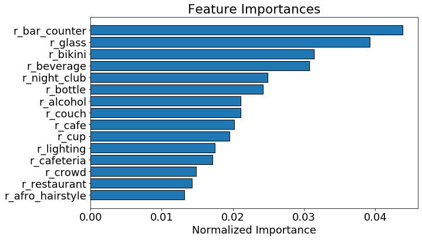

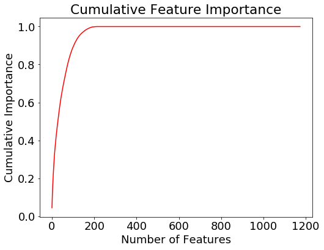

```
104 features required for 0.90 of cumulative importance
```

```python
norm_feature_importances = plot_feature_importances(feature_importances)
```

Let's remove the features that have zero importance.

```python
train = train.drop(columns = zero_features)
print('Training shape: ', train.shape)
```

```
Training shape:  (16568, 212)
```

At this point, we can re-run the model to see if it identifies any more features with zero importance. In a way, we are implementing our own form of recursive feature elimination. Since we are repeating work, we should probably put the zero feature importance identification code in a function.

```python
def identify_zero_importance_features(train, train_labels, iterations = 2):
    """
    Identify zero importance features in a training dataset based on the
    feature importances from a gradient boosting model.

    Parameters
    --------
    train : dataframe
        Training features

    train_labels : np.array
        Labels for training data

    iterations : integer, default = 2
        Number of cross validation splits to use for determining feature importances
    """

    # Initialize an empty array to hold feature importances
    feature_importances = np.zeros(train.shape[1])

    # Create the model with several hyperparameters
    model = lgb.LGBMClassifier(objective='binary', boosting_type = 'goss', n_estimators = 10000, class_weight = 'balanced')

    # Fit the model multiple times to avoid overfitting
    for i in range(iterations):

        # Split into training and validation set
        train_features, valid_features, train_y, valid_y = train_test_split(train, train_labels, test_size = 0.25, random_state = i)

        # Train using early stopping
        model.fit(train_features, train_y, early_stopping_rounds=100, eval_set = [(valid_features, valid_y)],
                  eval_metric = 'auc', verbose = 200)

        # Record the feature importances
        feature_importances += model.feature_importances_ / iterations

    feature_importances = pd.DataFrame({'feature': list(train.columns), 'importance': feature_importances}).sort_values('importance', ascending = False)

    # Find the features with zero importance
    zero_features = list(feature_importances[feature_importances['importance'] == 0.0]['feature'])
    print('\nThere are %d features with 0.0 importance' % len(zero_features))

    return zero_features, feature_importances
```

```python
second_round_zero_features, feature_importances = identify_zero_importance_features(train, train_labels)
```

```
Training until validation scores don't improve for 100 rounds
Early stopping, best iteration is:
[98]	valid_0's auc: 0.785217	valid_0's binary_logloss: 0.553731
Training until validation scores don't improve for 100 rounds
[200]	valid_0's auc: 0.778474	valid_0's binary_logloss: 0.544306
[400]	valid_0's auc: 0.781147	valid_0's binary_logloss: 0.530198
Early stopping, best iteration is:
[350]	valid_0's auc: 0.787389	valid_0's binary_logloss: 0.531585

There are 0 features with 0.0 importance
```

There are now no 0 importance features left (I expected this). If we want to remove more features, we will have to start with features that have a non-zero importance. One way we could do this is by retaining enough features to account for a threshold percentage of importance, such as 95%. At this point, let's keep enough features to account for 95% of the importance. Again, this is an arbitrary decision!

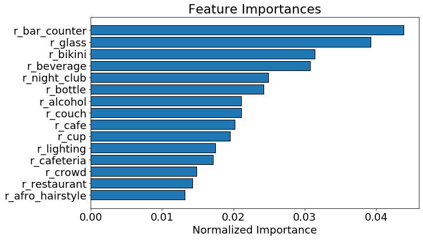

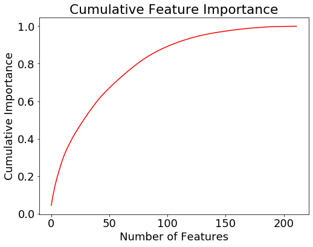

```
130 features required for 0.95 of cumulative importance
```

```python
norm_feature_importances = plot_feature_importances(feature_importances, threshold = 0.95)
```

We can keep only the features needed for 95% importance. This step seems to me to have the greatest chance of harming the model's learning ability, so rather than changing the original dataset, we will make smaller copies. Then, we can test both versions of the data to see if the extra feature removal step is worthwhile.

```python
threshold = 0.95
# Extract the features to keep
features_to_keep = list(norm_feature_importances[norm_feature_importances['cumulative_importance'] < threshold]['feature'])
# Create new datasets with smaller features
train_small = train[features_to_keep]
```

```python
train_small
dataset = pd.concat([train_small,train_labels], axis=1)
```

Feature Selection

The Recursive Feature Elimination (RFE) works by recursively removing variables and building a model on those variables that remain. It uses the model accuracy to identify which variables (and combination of variables) contribute the most to predicting the target attribute.

```python
df_vars=dataset.columns.values.tolist()
y=['h_alcohol_str']
X=[i for i in df_vars if i not in y]
model = LogisticRegression()
rfe = RFE(model, 10)
rfe = rfe.fit(df[X], df[y])
print(rfe.support_)
print(rfe.ranking_)
```

```
[ True False  True False False False False False False False False False
 False False False False False False False False False False False False
 False False False False False False False False False False False False
 False False False False False False False False False False False False
 False False False False False False False False False False False False
  True False False False False False  True False False False False False
 False False False False False  True False False False False False False
 False False False False False False False False False  True  True False
 False False False False False False False False False False False False
 False False False False False False False False  True False False False
 False False  True False  True False False False False]
[  1  10   1  36   9  22  95  75  85 116  54  86  47  28  55  70   5  27
  58  69 120 111 113 118  19  94  33  51  93  20  77  71  39  23  99  45
  92 101  67  73  21  46 103  13  76   4 119  43  40  52  97   6 108  14
   2  78  53  57  34  50   1  31  79  29  17  59   1  41 117  88  35  90
  61 100  62 102  12   1  42  63 112 104 109  82  98  60   7  66  25  84
  44 106  37   1   1  91  89  48 110  56 115  87  65  74 105  81  96   3
  18  80   8  83  72 114  11  49   1  64 107  32  30  38   1  68   1  26
  24  15  16]
```

You can see that RFE chose the 10 variables for us, which are marked True in the support_ array and marked with a choice “1” in the ranking_array.

```python
columns = dataset.columns.values.tolist()
columns
```

```
['r_bar_counter',
 'r_glass',
 'r_bikini',
 'r_beverage',
 'r_night_club',
 'r_bottle',
 'r_alcohol',
 'r_couch',
 'r_cafe',
 'r_cup',
 'r_lighting',
 'r_cafeteria',
 'r_crowd',
 'r_restaurant',
 'r_afro_hairstyle',
 'r_back',
 'r_sitting',
 'r_food',
 'r_bra',
 'r_hat',
 'r_plaid',
 'r_bust',
 'r_appliance',
 'r_lamp',
 'r_coat',
 'r_arm',
 'r_shop',
 'r_chair',
 'r_cardigan',
 'r_crypt',
 'r_vehicle',
 'r_tuxedo',
 'r_beard',
 'r_gown',
 'r_skin',
 'r_bling',
 'r_electronics',
 'r_dinner',
 'r_reception_room',
 'r_hug',
```

[output cut: 75 more lines]

```
 'r_blossom',
 'r_office_building',
 'r_kitchen',
 'r_blazer',
 'r_apartment_building',
 'r_living_room',
 'r_pillow',
 'r_fence',
 'r_entertainment_center',
 'r_dome',
 'r_school',
 'r_modern_art',
 'r_corridor',
 'r_bookcase',
 'h_alcohol_str']
```

```python
cols=['r_bar_counter','r_bottle','r_glass','r_bikini','r_night_club','r_flyer','r_beer','r_dirt_road','r_computer','r_office_building','r_fence','r_dome']
```

```python
X=train_small[cols]
y=dataset['h_alcohol_str']
```

# Logistic Regression Model

```python
X_train, X_test, y_train, y_test = train_test_split(X, y, test_size=0.3, random_state=0)
logreg = LogisticRegression()
logreg.fit(X_train, y_train)
```

```
LogisticRegression(C=1.0, class_weight=None, dual=False, fit_intercept=True,
                   intercept_scaling=1, l1_ratio=None, max_iter=100,
                   multi_class='warn', n_jobs=None, penalty='l2',
                   random_state=None, solver='warn', tol=0.0001, verbose=0,
                   warm_start=False)
```

```python
print('Logistic regression accuracy: {:.3f}'.format(accuracy_score(y_test, logreg.predict(X_test))))
```

```
Logistic regression accuracy: 0.820
```

# Random Forrest

```python
rf = RandomForestClassifier()
rf.fit(X_train, y_train)
```

```
RandomForestClassifier(bootstrap=True, class_weight=None, criterion='gini',
                       max_depth=None, max_features='auto', max_leaf_nodes=None,
                       min_impurity_decrease=0.0, min_impurity_split=None,
                       min_samples_leaf=1, min_samples_split=2,
                       min_weight_fraction_leaf=0.0, n_estimators=10,
                       n_jobs=None, oob_score=False, random_state=None,
                       verbose=0, warm_start=False)
```

```python
print('Random Forest Accuracy: {:.3f}'.format(accuracy_score(y_test, rf.predict(X_test))))
```

```
Random Forest Accuracy: 0.815
```

# Support Vector Machine

```python
svc = SVC()
svc.fit(X_train, y_train)
```

```
SVC(C=1.0, cache_size=200, class_weight=None, coef0=0.0,
    decision_function_shape='ovr', degree=3, gamma='auto_deprecated',
    kernel='rbf', max_iter=-1, probability=False, random_state=None,
    shrinking=True, tol=0.001, verbose=False)
```

```python
print('Support vector machine accuracy: {:.3f}'.format(accuracy_score(y_test, svc.predict(X_test))))
```

```
Support vector machine accuracy: 0.816
```

# Cross Validation

```python
kfold = model_selection.KFold(n_splits=10, random_state=7)
modelCV = LogisticRegression()
scoring = 'accuracy'
results = model_selection.cross_val_score(modelCV, X_train, y_train, cv=kfold, scoring=scoring)
print("10-fold cross validation average accuracy: %.3f" % (results.mean()))
```

```
10-fold cross validation average accuracy: 0.817
```

The average accuracy remains very close to the all 3 models we built; hence, we can conclude that the models generalizes well.

# Precision and recall

```python
print(classification_report(y_test, logreg.predict(X_test)))
```

```
              precision    recall  f1-score   support

         0.0       0.83      0.97      0.90      3993
         1.0       0.64      0.19      0.29       978

    accuracy                           0.82      4971
   macro avg       0.74      0.58      0.60      4971
weighted avg       0.79      0.82      0.78      4971
```

# Feature Importance for Random Forest Model

```python
feature_labels = np.array(['r_bar_counter','r_bottle','r_glass','r_bikini','r_night_club','r_flyer','r_beer','r_dirt_road','r_computer','r_office_building','r_fence','r_dome'])
importance = rf.feature_importances_
feature_indexes_by_importance = importance.argsort()
for index in feature_indexes_by_importance:
    print('{}-{:.2f}%'.format(feature_labels[index], (importance[index] *100.0)))
```

```
r_fence-1.03%
r_office_building-1.57%
r_dirt_road-2.03%
r_computer-2.17%
r_flyer-2.37%
r_dome-3.87%
r_beer-7.28%
r_night_club-9.85%
r_bottle-11.14%
r_bikini-11.80%
r_glass-22.68%
r_bar_counter-24.22%
```

We can still optimise this model by using other ways of feature extraction or by using other advanced models like XGB. Thank you